# Peak Calling & Peak2Gene Linkage

```r
## Load libraries


library(ArchR)
library(knitr)
library(rhdf5)
library(uwot)
library(tidyverse)
library(scater)
library(reticulate)
library(zellkonverter)
#library(caret)
h5disableFileLocking()
```

```r
# load ArchR project
proj <- loadArchRProject(path = "04_peak_calling_ArchRobject/")

# for R to find macs2 we will use a conda environment where the latest version
# of macs2 is installed
#conda_list()[[1]][1] %>% use_condaenv(required = TRUE)
```

# Pseudo-bulk replicates

For statistical significance we need replicates, which is not given in the binary single cell data obtained from scATAC-seq. Therefore, we create pseudo-bulk replicates. We group single cells and the data of all the cells in the group are combined into a pseudo-sample that resembles a bulk-ATAC-seq experiment. For each cell grouping several pseudo-bulks are created, resulting in pseudo-bulk replicates. The main assumption here is that the cells we group together are so similar that we are not interested in the differences between them. We group cells together based on clusters and known cell identities.

Parameters:

- minReps, maxReps: min. and max. number of replicates
- minCells, maxCells: min. and max. number of cells per replicate
- SamplingRatio: sampling ratio to use if a particular group of cells does not have required number e.g. 0.8 means that 80% of cells can be sampled without replacement for a particular replicate

Using the generated pseudo-bulk replicates, peak calling can be done.

The `groupBy` parameter specifies for which groups pseudo-bulk replicates should be made. With pseudo-bulks you can call peaks next, because we do not want to call peaks on all single cells together.

How many cells do we have for each celltype?

```r
getCellColData(proj) %>% as.data.frame() %>%
  mutate(timepoint = str_remove(Sample, "_rep[1-2]")) %>%
  group_by(celltypes, timepoint) %>% summarize(n = n()) %>% knitr::kable()
```

| celltypes | timepoint | n |
| --- | --- | --- |
| Allantois | E8.0 | 187 |
| Allantois | E8.5 | 303 |
| Anterior_Primitive_Streak | E7.5 | 28 |
| Blood_progenitors_1 | E7.5 | 95 |
| Blood_progenitors_1 | E8.0 | 7 |
| Blood_progenitors_1 | E8.5 | 9 |
| Blood_progenitors_2 | E7.5 | 120 |
| Blood_progenitors_2 | E8.0 | 265 |
| Blood_progenitors_2 | E8.5 | 15 |
| Cardiomyocytes | E8.0 | 192 |
| Cardiomyocytes | E8.5 | 308 |
| Caudal_epiblast | E7.5 | 211 |
| Caudal_epiblast | E8.0 | 272 |
| Caudal_epiblast | E8.5 | 43 |
| Caudal_Mesoderm | E7.5 | 14 |
| Caudal_Mesoderm | E8.0 | 162 |
| Caudal_Mesoderm | E8.5 | 47 |
| Caudal_neurectoderm | E7.5 | 1 |
| Caudal_neurectoderm | E8.0 | 24 |
| Caudal_neurectoderm | E8.5 | 4 |
| Def._endoderm | E7.5 | 161 |
| Def._endoderm | E8.0 | 42 |
| Def._endoderm | E8.5 | 36 |
| Endothelium | E8.0 | 147 |
| Endothelium | E8.5 | 289 |
| Epiblast | E7.5 | 1118 |
| Erythroid1 | E8.0 | 248 |
| Erythroid1 | E8.5 | 158 |
| Erythroid2 | E8.0 | 23 |
| Erythroid2 | E8.5 | 92 |

[output cut: 61 more lines]

```r
getCellColData(proj) %>% as.data.frame() %>%
  mutate(timepoint = str_remove(Sample, "_rep[1-2]")) %>%
  group_by(celltypes) %>% summarize(n = n()) %>% knitr::kable()
```

| celltypes | n |
| --- | --- |
| Allantois | 490 |
| Anterior_Primitive_Streak | 28 |
| Blood_progenitors_1 | 111 |
| Blood_progenitors_2 | 400 |
| Cardiomyocytes | 500 |
| Caudal_epiblast | 526 |
| Caudal_Mesoderm | 223 |
| Caudal_neurectoderm | 29 |
| Def._endoderm | 239 |
| Endothelium | 436 |
| Epiblast | 1118 |
| Erythroid1 | 406 |
| Erythroid2 | 115 |
| Erythroid3 | 740 |
| ExE_ectoderm | 2512 |
| ExE_endoderm | 4676 |
| ExE_mesoderm | 706 |
| Forebrain_Midbrain_Hindbrain | 1566 |
| Gut | 989 |
| Haematoendothelial_progenitors | 465 |
| Intermediate_mesoderm | 810 |
| Mesenchyme | 2243 |
| Mixed_mesoderm | 160 |
| Nascent_mesoderm | 1023 |
| Neural_crest | 124 |
| NMP | 754 |
| Notochord | 97 |
| Paraxial_mesoderm | 1135 |
| Parietal_endoderm | 290 |
| PGC | 17 |
| Pharyngeal_mesoderm | 859 |
| Primitive_Streak | 207 |
| Rostral_neurectoderm | 880 |
| Somitic_mesoderm | 907 |
| Spinal_cord | 763 |
| Surface_ectoderm | 1303 |
| Visceral_endoderm | 307 |

```
proj <- addGroupCoverages(ArchRProj = proj, groupBy = "celltypes",
                          force = FALSE)
```

# Peak calling

https://hbctraining.github.io/Intro-to-ChIPseq/lessons/05_peak_calling_macs.html

Because the scATAC-seq data is binary, peaks cannot be called on single cells. Using pseuodo-bulk replicates we can assess the reproducibility of our peak calls.

ArchR uses a fixed peak width as opposed to a variable peak width, because then peak length does not need to be normalized and it is easier to merge peaks from different saples. The peak length used is 501bp, since most peaks are smaller than 501 bp.

## Iterative Overlap

1. rank peaks by their signficance
2. the most significant peak is retained
3. any peak overlapping with the most significant peak is removed
4. the process is repeated for the remaining peaks

For example, if we hae 3 ell types A, B, C and 3 pseudo-bulk replicates for each:

1. Call peaks for each pseudo-bulk replicate individually
2. The first iteration of iterative overlap would then be performed on all pseuo- bulk replicates from a single cell type. (It is important to normalize peak significance across different samples beforehand)
3. Check the reproducibility of each peak across pseud9-bulk replicates and only keep the peaks that pass a threshold
4. You now have a single merged peak set for each of the 3 cell types
5. proceed with iterative overlap remove to merge A, B, C peak sets (It is important to re-normalize the peak significance across different cell types at this step)

**At the end you are left with a single merged peak set of fixed-width peaks.**

Cell are then defined as accessible at a particular peak if a read from that cell overlapped the peak.

We set the minimum number of cells used to call a peak to 25, this way we will exclude pseudo-bulk replicates with very low cell number.

```r
addArchRThreads(1)
#pathToMacs2 <- findMacs2()
```

```
proj <- addReproduciblePeakSet(
    ArchRProj = proj,
    groupBy = "celltypes",
    pathToMacs2 = "/omics/groups/OE0533/internal/katharina/R_env/bin/macs2",
    minCells = 25, # minimum allowable number of unique cells that was used to
    #create the coverage files on which peaks are called. Pseudo-bulk replicates
    #derived from very low cell numbers are excluded.
    force = FALSE
)
```

```r
peakset <- ArchR::getPeakSet(proj) %>%
  tibble::as_tibble()
print(paste0("Dimensions of the peak set are: ", paste(dim(peakset), collapse=", ")))
## [1] "Dimensions of the peak set are: 512953, 18"
```

```r
peakset %>%
  glimpse()
## Rows: 512,953
## Columns: 18
## $ seqnames               <fct> chr1, chr1, chr1, chr1, chr1, chr1, chr1, chr1,…
## $ start                  <int> 3005585, 3008841, 3012479, 3035629, 3044212, 30…
## $ end                    <int> 3006085, 3009341, 3012979, 3036129, 3044712, 30…
## $ width                  <int> 501, 501, 501, 501, 501, 501, 501, 501, 501, 50…
## $ strand                 <fct> *, *, *, *, *, *, *, *, *, *, *, *, *, *, *, *,…
## $ score                  <dbl> 7.59353, 6.01780, 21.03510, 18.65140, 4.92875, …
## $ replicateScoreQuantile <dbl> 0.551, 0.362, 0.616, 0.709, 0.180, 0.728, 0.430…
## $ groupScoreQuantile     <dbl> 0.434, 0.204, 0.548, 0.639, 0.068, 0.683, 0.324…
## $ Reproducibility        <dbl> 2, 3, 4, 4, 2, 5, 3, 5, 5, 5, 2, 5, 5, 5, 3, 4,…
## $ GroupReplicate         <chr> "Forebrain_Midbrain_Hindbrain._.E8.0_rep1", "In…
## $ distToGeneStart        <int> 665662, 662406, 658768, 635618, 627035, 626229,…
## $ nearestGene            <chr> "Xkr4", "Xkr4", "Xkr4", "Xkr4", "Xkr4", "Xkr4",…
## $ peakType               <chr> "Distal", "Distal", "Distal", "Distal", "Distal…
## $ distToTSS              <int> 209796, 206540, 202902, 179752, 171169, 170363,…
## $ nearestTSS             <chr> "uc007aet.1", "uc007aet.1", "uc007aet.1", "uc00…
## $ GC                     <dbl> 0.4012, 0.4511, 0.3473, 0.4291, 0.3932, 0.4950,…
## $ idx                    <int> 1, 2, 3, 4, 5, 6, 7, 8, 9, 10, 11, 12, 13, 14, …
## $ N                      <dbl> 0, 0, 0, 0, 0, 0, 0, 0, 0, 0, 0, 0, 0, 0, 0, 0,…
```

```r
peakset %>%
  dplyr::count(peakType)
## # A tibble: 4 × 2
##   peakType      n
##   <chr>     <int>
## 1 Distal   210240
## 2 Exonic    25790
## 3 Intronic 240825
## 4 Promoter  36098
```

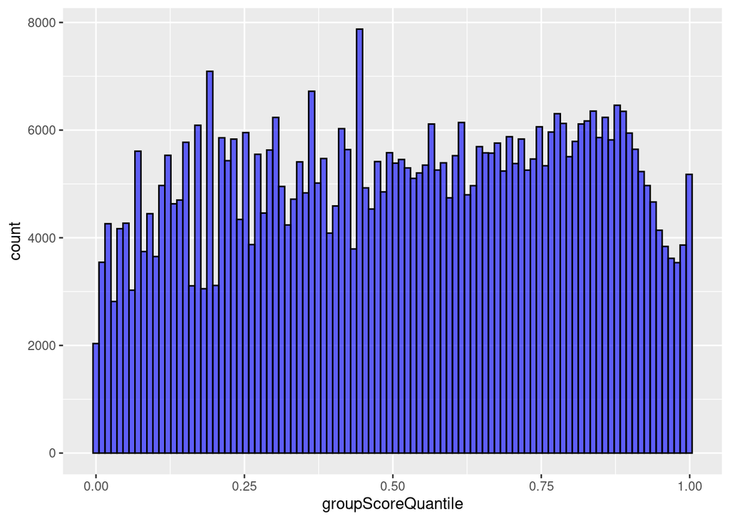

```r
peakset %>%
  ggplot() +
  geom_histogram(aes(x=groupScoreQuantile), bins=100, fill = "blue",
                 color = "black", alpha = 0.6)
```

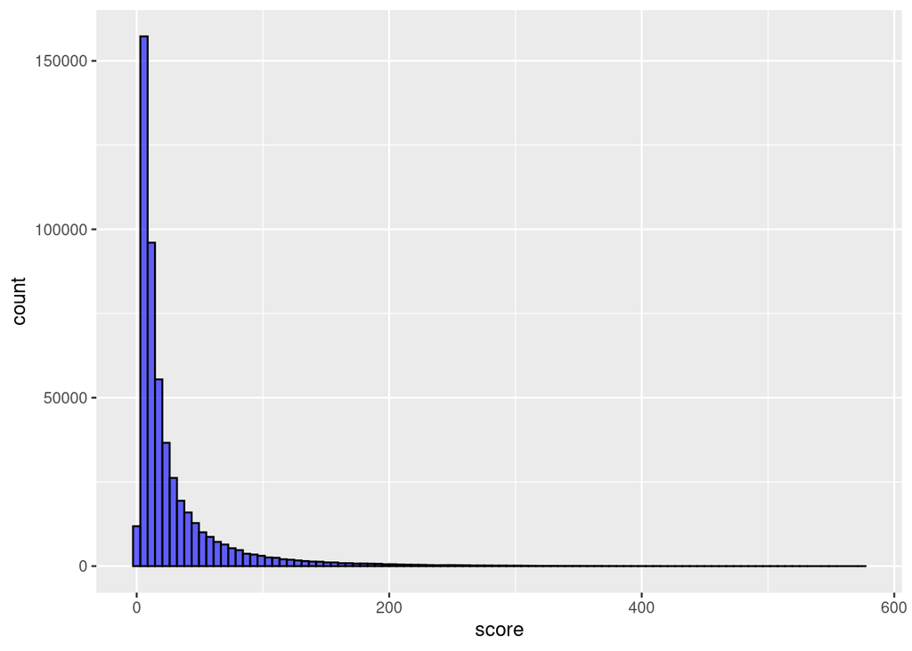

```r
peakset %>%
  ggplot() +
  geom_histogram(aes(x=score), bins=100, fill = "blue",
                 color = "black", alpha = 0.6)
```

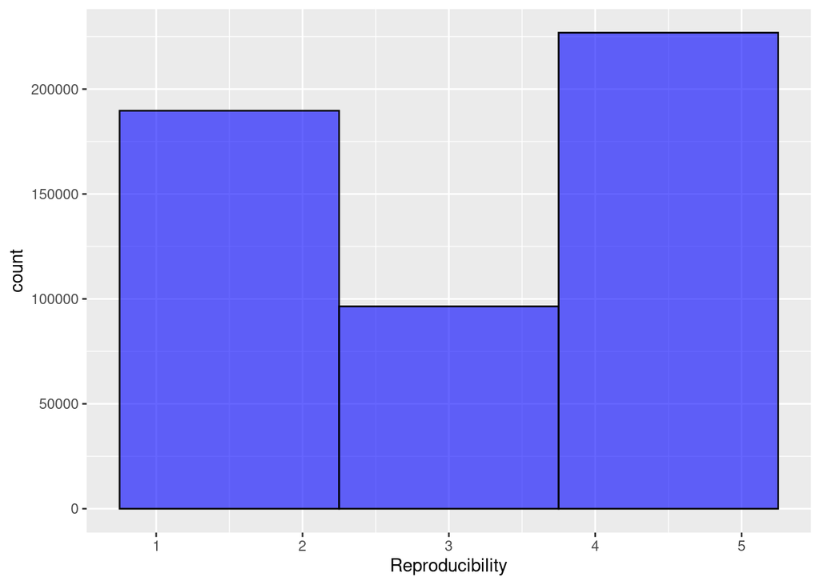

```r
peakset %>%
  ggplot() +
  geom_histogram(aes(x=Reproducibility), bins=3, fill = "blue",
                 color = "black", alpha = 0.6)
```

Lets have a look for which time stages there where enough cells to call peaks and how many peaks were called in each case.

```r
peakset %>% group_by(GroupReplicate) %>% summarise(n = n())
## # A tibble: 131 × 2
##    GroupReplicate                      n
##    <chr>                           <int>
##  1 Allantois._.E8.0_rep1            3646
##  2 Allantois._.E8.0_rep2            5425
##  3 Allantois._.E8.5_rep1            4577
##  4 Allantois._.E8.5_rep2            2450
##  5 Blood_progenitors_1._.E7.5_rep1    79
##  6 Blood_progenitors_1._.E7.5_rep2   429
##  7 Blood_progenitors_2._.E7.5_rep1   736
##  8 Blood_progenitors_2._.E7.5_rep2  2908
##  9 Blood_progenitors_2._.E8.0_rep1  1225
## 10 Blood_progenitors_2._.E8.0_rep2  1063
## # … with 121 more rows
```

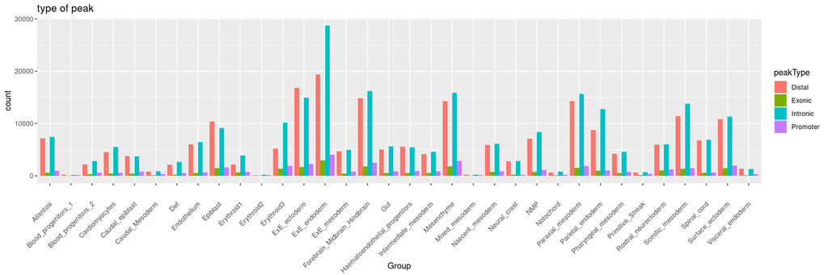

```r
peakset <- as_data_frame(peakset)
## Warning: `as_data_frame()` was deprecated in tibble 2.0.0.
## Please use `as_tibble()` instead.
## The signature and semantics have changed, see `?as_tibble`.

p1 <- peakset %>%
  mutate(Group = str_extract(peakset[["GroupReplicate"]], "(?<!.)[^.]+")) %>%
  ggplot() +
  geom_bar(aes(x = Group, fill = peakType), position = "dodge") +
  labs(title = "type of peak") +
  theme(axis.text.x = element_text(angle = 45, vjust = 0.8, hjust=1))
p1
```

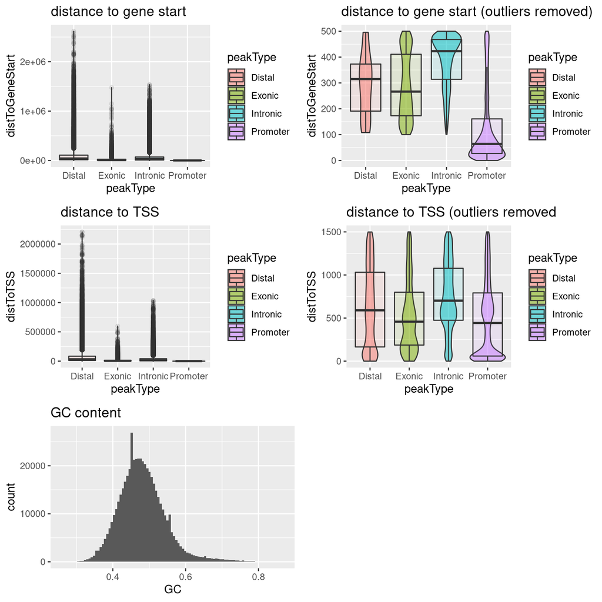

```r
p2 <- peakset %>%
  ggplot() +
  geom_violin(aes(x = peakType, y = distToGeneStart, fill = peakType),
              alpha = .5) +
  geom_boxplot(aes(x = peakType, y = distToGeneStart, fill = peakType),
               alpha = .1) +
  labs(title = "distance to gene start")

p3 <- peakset %>%
  ggplot() +
  geom_violin(aes(x = peakType, y = distToGeneStart, fill = peakType), outlier.shape = NA,
              alpha = .5) +
  geom_boxplot(aes(x = peakType, y = distToGeneStart, fill = peakType), outlier.shape = NA,
               alpha = .1) +
  ylim(0, 500) +
  labs(title = "distance to gene start (outliers removed)")
## Warning: Ignoring unknown parameters: outlier.shape

p4 <- peakset %>%
  ggplot() +
  geom_violin(aes(x = peakType, y = distToTSS, fill = peakType),
                  alpha = .5) +
  geom_boxplot(aes(x = peakType, y = distToTSS, fill = peakType), alpha = .1) +
  labs(title = "distance to TSS")

p5 <- peakset %>%
  ggplot() +
  geom_violin(aes(x = peakType, y = distToTSS, fill = peakType),
                  alpha = .5, outlier.shape = NA ) +
  geom_boxplot(aes(x = peakType, y = distToTSS, fill = peakType),
               alpha = .1, outlier.shape = NA) +
  ylim(0, 1500) +
  labs(title = "distance to TSS (outliers removed")
## Warning: Ignoring unknown parameters: outlier.shape

p6 <- peakset %>%
  mutate(Group = str_extract(peakset[["GroupReplicate"]], "(?<!.)[^.]+")) %>%
  ggplot() +
  geom_histogram(aes(x = GC), bins = 100) +
  labs(title = "GC content")

p7 <- peakset %>%
  mutate(Group = str_extract(peakset[["GroupReplicate"]], "(?<!.)[^.]+")) %>%
  ggplot() +
  geom_violin(aes(x = Group, y = GC, fill = Group), alpha = .5) +
  geom_boxplot(aes(x = Group, y = GC, fill = Group), alpha = .1) +
  labs(title = "GC content")


gridExtra::grid.arrange(p2, p3, p4, p5, p6, ncol = 2)
## Warning: Removed 491427 rows containing non-finite values (stat_ydensity).
## Warning: Removed 491427 rows containing non-finite values (stat_boxplot).
## Warning: Removed 445737 rows containing non-finite values (stat_ydensity).
## Warning: Removed 445737 rows containing non-finite values (stat_boxplot).
```

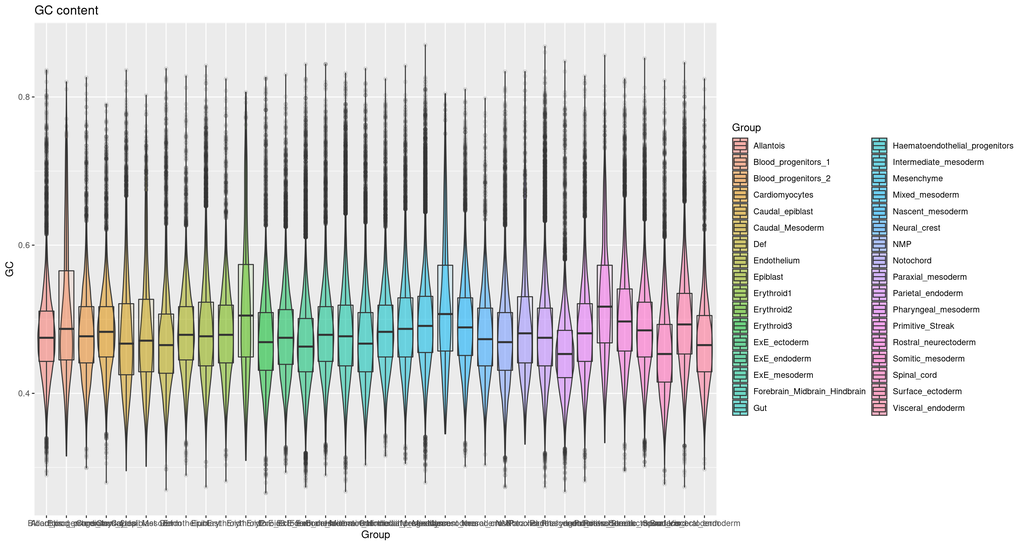

```r
p7
```

We will add the peak matrix to the ArchR object.

```
`proj <- addPeakMatrix(ArchRProj = proj,
                      verbose = FALSE,
                      force = FALSE)
```

```r
#saveArchRProject(proj, outputDirectory = "04_peak_calling_ArchRobject", load = FALSE)
```

What are our available matrices after this step?

```r
getAvailableMatrices(proj)
## [1] "GeneExpressionMatrix" "GeneScoreMatrix"      "PeakMatrix"
## [4] "TileMatrix"
```

```r
peakMatrix <- getMatrixFromProject(ArchRProj = proj,
                                   useMatrix = "PeakMatrix",
                                   verbose = FALSE)


print(paste0("Dimensions of the peak matrix are:", paste(dim(peakMatrix), collapse = ", ")))
## [1] "Dimensions of the peak matrix are:512953, 28154"
```

# Getting peaks2gene links took less than 5 minutes.

```
proj <- addPeak2GeneLinks(  ArchRProj = proj,
  reducedDims  = "atac_LSI_100000",
  useMatrix = "GeneExpressionMatrix",
  maxDist = 250000,
  verbose = FALSE,
  )
```

Lets have a look at the peak2gene links:

```r
p2g <- getPeak2GeneLinks(
  ArchRProj = proj,
  corCutOff = -1,
  resolution = 1,
  FDRCutOff = 1e-04,
  varCutOffATAC = .25,
  varCutOffRNA = .25,
  returnLoops = FALSE
)
```

```r
# convert the output to a tibble
p2g %>% as_tibble() %>% head() %>% knitr::kable()
```

| idxATAC | idxRNA | Correlation | FDR | VarQATAC | VarQRNA |
| --- | --- | --- | --- | --- | --- |
| 4 | 1 | 0.4447460 | 0 | 0.7037604 | 0.9725228 |
| 6 | 1 | -0.3366633 | 0 | 0.8375309 | 0.9725228 |
| 7 | 1 | -0.2650031 | 0 | 0.3021349 | 0.9725228 |
| 8 | 1 | -0.2893693 | 0 | 0.6282291 | 0.9725228 |
| 9 | 1 | 0.7472881 | 0 | 0.7915209 | 0.9725228 |
| 10 | 1 | -0.3152997 | 0 | 0.8777783 | 0.9725228 |

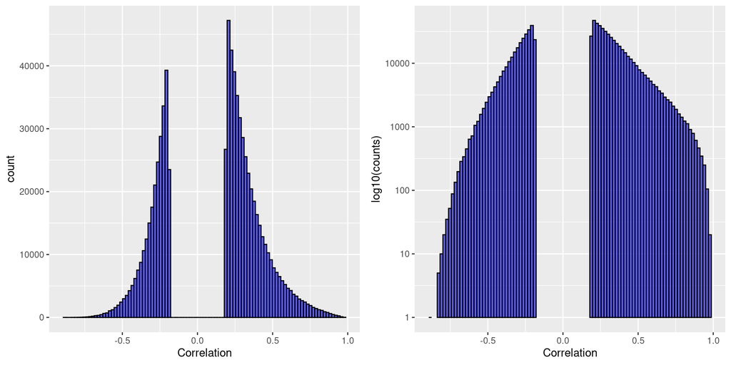

```r
p1 <- p2g %>% as_tibble() %>% ggplot() +
  geom_histogram(aes(x = Correlation), bins = 100, fill = "blue",
                 color = "black", alpha = .6)

p2 <- p2g %>% as_tibble() %>% ggplot() +
  geom_histogram(aes(x = Correlation), bins = 100, fill = "blue",
                 color = "black", alpha = .6) +
  scale_y_log10() +
  labs(y = "log10(counts)")

gridExtra::grid.arrange(p1, p2, ncol = 2)
## Warning: Transformation introduced infinite values in continuous y-axis
## Warning: Removed 21 rows containing missing values (geom_bar).
```